# Part I - (Ford GoBike System Data Exploration)

## by (Chinonso Peace Mbama)

## Introduction

> This data set includes information about individual rides made in Ford bike-sharing system covering the greater San Francisco Bay area.

## Preliminary Wrangling

```python
# import all packages and set plots to be embedded inline
import numpy as np
import pandas as pd
import matplotlib.pyplot as plt
import seaborn as sb
import glob

%matplotlib inline
```

```python
# Load in the dataset into pandas fataframe
df_main = None

for filename in sorted(glob.glob('ford-gobike-tripdata.csv')):
    if df_main is None:
        df_main = pd.read_csv('ford-gobike-tripdata.csv')
    else:
        temp = pd.read_csv('ford-gobike-tripdata.csv')
        df_main = df.append(temp, ignore_index=True)
```

## ASSESS DATA

```python
# view dataframe
df_main
```

|  | duration_sec | start_time | end_time | start_station_id | start_station_name | start_station_latitude | start_station_longitude | end_station_id | end_station_name | end_station_latitude | end_station_longitude | bike_id | user_type | member_birth_year | member_gender | bike_share_for_all_trip |
| --- | --- | --- | --- | --- | --- | --- | --- | --- | --- | --- | --- | --- | --- | --- | --- | --- |
| 0 | 52185 | 2019-02-28 17:32:10.1450 | 2019-03-01 08:01:55.9750 | 21.0 | Montgomery St BART Station (Market St at 2nd St) | 37.789625 | -122.400811 | 13.0 | Commercial St at Montgomery St | 37.794231 | -122.402923 | 4902 | Customer | 1984.0 | Male | No |
| 1 | 42521 | 2019-02-28 18:53:21.7890 | 2019-03-01 06:42:03.0560 | 23.0 | The Embarcadero at Steuart St | 37.791464 | -122.391034 | 81.0 | Berry St at 4th St | 37.775880 | -122.393170 | 2535 | Customer | NaN | NaN | No |
| 2 | 61854 | 2019-02-28 12:13:13.2180 | 2019-03-01 05:24:08.1460 | 86.0 | Market St at Dolores St | 37.769305 | -122.426826 | 3.0 | Powell St BART Station (Market St at 4th St) | 37.786375 | -122.404904 | 5905 | Customer | 1972.0 | Male | No |
| 3 | 36490 | 2019-02-28 17:54:26.0100 | 2019-03-01 04:02:36.8420 | 375.0 | Grove St at Masonic Ave | 37.774836 | -122.446546 | 70.0 | Central Ave at Fell St | 37.773311 | -122.444293 | 6638 | Subscriber | 1989.0 | Other | No |
| 4 | 1585 | 2019-02-28 23:54:18.5490 | 2019-03-01 00:20:44.0740 | 7.0 | Frank H Ogawa Plaza | 37.804562 | -122.271738 | 222.0 | 10th Ave at E 15th St | 37.792714 | -122.248780 | 4898 | Subscriber | 1974.0 | Male | Yes |
| ... | ... | ... | ... | ... | ... | ... | ... | ... | ... | ... | ... | ... | ... | ... | ... | ... |
| 183407 | 480 | 2019-02-01 00:04:49.7240 | 2019-02-01 00:12:50.0340 | 27.0 | Beale St at Harrison St | 37.788059 | -122.391865 | 324.0 | Union Square (Powell St at Post St) | 37.788300 | -122.408531 | 4832 | Subscriber | 1996.0 | Male | No |
| 183408 | 313 | 2019-02-01 00:05:34.7440 | 2019-02-01 00:10:48.5020 | 21.0 | Montgomery St BART Station (Market St at 2nd St) | 37.789625 | -122.400811 | 66.0 | 3rd St at Townsend St | 37.778742 | -122.392741 | 4960 | Subscriber | 1984.0 | Male | No |
| 183409 | 141 | 2019-02-01 00:06:05.5490 | 2019-02-01 00:08:27.2200 | 278.0 | The Alameda at Bush St | 37.331932 | -121.904888 | 277.0 | Morrison Ave at Julian St | 37.333658 | -121.908586 | 3824 | Subscriber | 1990.0 | Male | Yes |
| 183410 | 139 | 2019-02-01 00:05:34.3600 | 2019-02-01 00:07:54.2870 | 220.0 | San Pablo Ave at MLK Jr Way | 37.811351 | -122.273422 | 216.0 | San Pablo Ave at 27th St | 37.817827 | -122.275698 | 5095 | Subscriber | 1988.0 | Male | No |
| 183411 | 271 | 2019-02-01 00:00:20.6360 | 2019-02-01 00:04:52.0580 | 24.0 | Spear St at Folsom St | 37.789677 | -122.390428 | 37.0 | 2nd St at Folsom St | 37.785000 | -122.395936 | 1057 | Subscriber | 1989.0 | Male | No |

183412 rows × 16 columns

```python
# View dataframe info
df_main.info()
```

```
<class 'pandas.core.frame.DataFrame'>
RangeIndex: 183412 entries, 0 to 183411
Data columns (total 16 columns):
 #   Column                   Non-Null Count   Dtype
---  ------                   --------------   -----
 0   duration_sec             183412 non-null  int64
 1   start_time               183412 non-null  object
 2   end_time                 183412 non-null  object
 3   start_station_id         183215 non-null  float64
 4   start_station_name       183215 non-null  object
 5   start_station_latitude   183412 non-null  float64
 6   start_station_longitude  183412 non-null  float64
 7   end_station_id           183215 non-null  float64
 8   end_station_name         183215 non-null  object
 9   end_station_latitude     183412 non-null  float64
 10  end_station_longitude    183412 non-null  float64
 11  bike_id                  183412 non-null  int64
 12  user_type                183412 non-null  object
 13  member_birth_year        175147 non-null  float64
 14  member_gender            175147 non-null  object
 15  bike_share_for_all_trip  183412 non-null  object
dtypes: float64(7), int64(2), object(7)
memory usage: 22.4+ MB
```

```python
# View number of dataframe rows and columns
df_main.shape
```

```
(183412, 16)
```

```python
# View number of null values in each column
df_main.isnull().sum()
```

```
duration_sec                  0
start_time                    0
end_time                      0
start_station_id            197
start_station_name          197
start_station_latitude        0
start_station_longitude       0
end_station_id              197
end_station_name            197
end_station_latitude          0
end_station_longitude         0
bike_id                       0
user_type                     0
member_birth_year          8265
member_gender              8265
bike_share_for_all_trip       0
dtype: int64
```

```python
# View datatypes for each column
df_main.dtypes
```

```
duration_sec                 int64
start_time                  object
end_time                    object
start_station_id           float64
start_station_name          object
start_station_latitude     float64
start_station_longitude    float64
end_station_id             float64
end_station_name            object
end_station_latitude       float64
end_station_longitude      float64
bike_id                      int64
user_type                   object
member_birth_year          float64
member_gender               object
bike_share_for_all_trip     object
dtype: object
```

#### Based on the assesment of the data, the following quality and tidyness issues were discovered:

> 1. Start_station_id, start_station_name, end_station_id, end_station_name, members_birth_year and member_gender all have null values in them, all the null values will be dropped.
> 2. Columns that are not relevant to the visualisation will be dropped namely: 'start_station_latitude', 'start_station_longitude', 'end_station_latitude', 'end_station_longitude'.
> 3. Datatypes for the listed columns will be changed thus: start_station_id': 'str', 'end_station_id': 'str','bike_id': 'str', 'user_type': 'category', 'bike_share_for_all_trip':'category', timestamp to datetime.
> 4. Split start_time and end_time to month, week and hour.
> 5. Duration_sec will be chieseled to duration_by minutes.
> 6. All member_gender identified as others will be dropped

## CLEANING DATA

```python
# Make a copy of the main data
df_clean = df_main.copy()
```

```python
# 1. Drop null values
df_clean.dropna(inplace=True)
```

```python
# test
df_clean.info()
```

```
<class 'pandas.core.frame.DataFrame'>
Int64Index: 174952 entries, 0 to 183411
Data columns (total 16 columns):
 #   Column                   Non-Null Count   Dtype
---  ------                   --------------   -----
 0   duration_sec             174952 non-null  int64
 1   start_time               174952 non-null  object
 2   end_time                 174952 non-null  object
 3   start_station_id         174952 non-null  float64
 4   start_station_name       174952 non-null  object
 5   start_station_latitude   174952 non-null  float64
 6   start_station_longitude  174952 non-null  float64
 7   end_station_id           174952 non-null  float64
 8   end_station_name         174952 non-null  object
 9   end_station_latitude     174952 non-null  float64
 10  end_station_longitude    174952 non-null  float64
 11  bike_id                  174952 non-null  int64
 12  user_type                174952 non-null  object
 13  member_birth_year        174952 non-null  float64
 14  member_gender            174952 non-null  object
 15  bike_share_for_all_trip  174952 non-null  object
dtypes: float64(7), int64(2), object(7)
memory usage: 22.7+ MB
```

```python
df_clean.head()
```

|  | duration_sec | start_time | end_time | start_station_id | start_station_name | start_station_latitude | start_station_longitude | end_station_id | end_station_name | end_station_latitude | end_station_longitude | bike_id | user_type | member_birth_year | member_gender | bike_share_for_all_trip |
| --- | --- | --- | --- | --- | --- | --- | --- | --- | --- | --- | --- | --- | --- | --- | --- | --- |
| 0 | 52185 | 2019-02-28 17:32:10.1450 | 2019-03-01 08:01:55.9750 | 21.0 | Montgomery St BART Station (Market St at 2nd St) | 37.789625 | -122.400811 | 13.0 | Commercial St at Montgomery St | 37.794231 | -122.402923 | 4902 | Customer | 1984.0 | Male | No |
| 2 | 61854 | 2019-02-28 12:13:13.2180 | 2019-03-01 05:24:08.1460 | 86.0 | Market St at Dolores St | 37.769305 | -122.426826 | 3.0 | Powell St BART Station (Market St at 4th St) | 37.786375 | -122.404904 | 5905 | Customer | 1972.0 | Male | No |
| 3 | 36490 | 2019-02-28 17:54:26.0100 | 2019-03-01 04:02:36.8420 | 375.0 | Grove St at Masonic Ave | 37.774836 | -122.446546 | 70.0 | Central Ave at Fell St | 37.773311 | -122.444293 | 6638 | Subscriber | 1989.0 | Other | No |
| 4 | 1585 | 2019-02-28 23:54:18.5490 | 2019-03-01 00:20:44.0740 | 7.0 | Frank H Ogawa Plaza | 37.804562 | -122.271738 | 222.0 | 10th Ave at E 15th St | 37.792714 | -122.248780 | 4898 | Subscriber | 1974.0 | Male | Yes |
| 5 | 1793 | 2019-02-28 23:49:58.6320 | 2019-03-01 00:19:51.7600 | 93.0 | 4th St at Mission Bay Blvd S | 37.770407 | -122.391198 | 323.0 | Broadway at Kearny | 37.798014 | -122.405950 | 5200 | Subscriber | 1959.0 | Male | No |

```python
# check for duplicates
df_clean.duplicated().sum()
```

```
0
```

```python
# 2. Drop unnecessary columns
df_clean = df_clean.drop(['start_station_latitude', 'start_station_longitude', 'end_station_latitude',
               'end_station_longitude'], axis=1)
```

```python
# 3. change the dtype for timestamp to datetime
df_clean['start_time'] = pd.to_datetime(df_clean['start_time'])
df_clean['end_time'] = pd.to_datetime(df_clean['end_time'])
```

```python
# Test
df_clean.info()
```

```
<class 'pandas.core.frame.DataFrame'>
Int64Index: 174952 entries, 0 to 183411
Data columns (total 12 columns):
 #   Column                   Non-Null Count   Dtype
---  ------                   --------------   -----
 0   duration_sec             174952 non-null  int64
 1   start_time               174952 non-null  datetime64[ns]
 2   end_time                 174952 non-null  datetime64[ns]
 3   start_station_id         174952 non-null  float64
 4   start_station_name       174952 non-null  object
 5   end_station_id           174952 non-null  float64
 6   end_station_name         174952 non-null  object
 7   bike_id                  174952 non-null  int64
 8   user_type                174952 non-null  object
 9   member_birth_year        174952 non-null  float64
 10  member_gender            174952 non-null  object
 11  bike_share_for_all_trip  174952 non-null  object
dtypes: datetime64[ns](2), float64(3), int64(2), object(5)
memory usage: 17.4+ MB
```

```python
# 3. Change other datatypes
dtype= {'start_station_id': 'str', 'end_station_id': 'str','bike_id': 'str', 'user_type': 'category', 'bike_share_for_all_trip':'category'}
df_clean = df_clean.astype(dtype)
```

```python
# Test
df_clean.info()
```

```
<class 'pandas.core.frame.DataFrame'>
Int64Index: 174952 entries, 0 to 183411
Data columns (total 12 columns):
 #   Column                   Non-Null Count   Dtype
---  ------                   --------------   -----
 0   duration_sec             174952 non-null  int64
 1   start_time               174952 non-null  datetime64[ns]
 2   end_time                 174952 non-null  datetime64[ns]
 3   start_station_id         174952 non-null  object
 4   start_station_name       174952 non-null  object
 5   end_station_id           174952 non-null  object
 6   end_station_name         174952 non-null  object
 7   bike_id                  174952 non-null  object
 8   user_type                174952 non-null  category
 9   member_birth_year        174952 non-null  float64
 10  member_gender            174952 non-null  object
 11  bike_share_for_all_trip  174952 non-null  category
dtypes: category(2), datetime64[ns](2), float64(1), int64(1), object(6)
memory usage: 15.0+ MB
```

```python
df_clean.head()
```

|  | duration_sec | start_time | end_time | start_station_id | start_station_name | end_station_id | end_station_name | bike_id | user_type | member_birth_year | member_gender | bike_share_for_all_trip |
| --- | --- | --- | --- | --- | --- | --- | --- | --- | --- | --- | --- | --- |
| 0 | 52185 | 2019-02-28 17:32:10.145 | 2019-03-01 08:01:55.975 | 21.0 | Montgomery St BART Station (Market St at 2nd St) | 13.0 | Commercial St at Montgomery St | 4902 | Customer | 1984.0 | Male | No |
| 2 | 61854 | 2019-02-28 12:13:13.218 | 2019-03-01 05:24:08.146 | 86.0 | Market St at Dolores St | 3.0 | Powell St BART Station (Market St at 4th St) | 5905 | Customer | 1972.0 | Male | No |
| 3 | 36490 | 2019-02-28 17:54:26.010 | 2019-03-01 04:02:36.842 | 375.0 | Grove St at Masonic Ave | 70.0 | Central Ave at Fell St | 6638 | Subscriber | 1989.0 | Other | No |
| 4 | 1585 | 2019-02-28 23:54:18.549 | 2019-03-01 00:20:44.074 | 7.0 | Frank H Ogawa Plaza | 222.0 | 10th Ave at E 15th St | 4898 | Subscriber | 1974.0 | Male | Yes |
| 5 | 1793 | 2019-02-28 23:49:58.632 | 2019-03-01 00:19:51.760 | 93.0 | 4th St at Mission Bay Blvd S | 323.0 | Broadway at Kearny | 5200 | Subscriber | 1959.0 | Male | No |

```python
# 4. Split start_time to month, weekday and hour
df_clean['month_started'] = df_clean.start_time.dt.month
df_clean['week_started'] = df_clean.start_time.dt.weekday
df_clean['hour_started'] = df_clean.start_time.dt.hour
```

```python
# 4. Split end_time to month, weekday and hour
df_clean['month_ended'] = df_clean.end_time.dt.month
df_clean['week_ended'] = df_clean.end_time.dt.weekday
df_clean['hour_ended'] = df_clean.end_time.dt.hour
```

```python
# 5. Duration_sec will be chieseled to duration_by minutes.
df_clean['duration_by_minutes'] = df_clean['duration_sec']/60
```

```python
# 6. All member_gender identified as others will be dropped
df_clean = df_clean[df_clean['member_gender'] != 'Other']
```

```python
# Test
df_clean.head()
```

|  | duration_sec | start_time | end_time | start_station_id | start_station_name | end_station_id | end_station_name | bike_id | user_type | member_birth_year | member_gender | bike_share_for_all_trip | month_started | week_started | hour_started | month_ended | week_ended | hour_ended | duration_by_minutes |
| --- | --- | --- | --- | --- | --- | --- | --- | --- | --- | --- | --- | --- | --- | --- | --- | --- | --- | --- | --- |
| 0 | 52185 | 2019-02-28 17:32:10.145 | 2019-03-01 08:01:55.975 | 21.0 | Montgomery St BART Station (Market St at 2nd St) | 13.0 | Commercial St at Montgomery St | 4902 | Customer | 1984.0 | Male | No | 2 | 3 | 17 | 3 | 4 | 8 | 869.750000 |
| 2 | 61854 | 2019-02-28 12:13:13.218 | 2019-03-01 05:24:08.146 | 86.0 | Market St at Dolores St | 3.0 | Powell St BART Station (Market St at 4th St) | 5905 | Customer | 1972.0 | Male | No | 2 | 3 | 12 | 3 | 4 | 5 | 1030.900000 |
| 4 | 1585 | 2019-02-28 23:54:18.549 | 2019-03-01 00:20:44.074 | 7.0 | Frank H Ogawa Plaza | 222.0 | 10th Ave at E 15th St | 4898 | Subscriber | 1974.0 | Male | Yes | 2 | 3 | 23 | 3 | 4 | 0 | 26.416667 |
| 5 | 1793 | 2019-02-28 23:49:58.632 | 2019-03-01 00:19:51.760 | 93.0 | 4th St at Mission Bay Blvd S | 323.0 | Broadway at Kearny | 5200 | Subscriber | 1959.0 | Male | No | 2 | 3 | 23 | 3 | 4 | 0 | 29.883333 |
| 6 | 1147 | 2019-02-28 23:55:35.104 | 2019-03-01 00:14:42.588 | 300.0 | Palm St at Willow St | 312.0 | San Jose Diridon Station | 3803 | Subscriber | 1983.0 | Female | No | 2 | 3 | 23 | 3 | 4 | 0 | 19.116667 |

```python
df_clean.info()
```

```
<class 'pandas.core.frame.DataFrame'>
Int64Index: 171305 entries, 0 to 183411
Data columns (total 19 columns):
 #   Column                   Non-Null Count   Dtype
---  ------                   --------------   -----
 0   duration_sec             171305 non-null  int64
 1   start_time               171305 non-null  datetime64[ns]
 2   end_time                 171305 non-null  datetime64[ns]
 3   start_station_id         171305 non-null  object
 4   start_station_name       171305 non-null  object
 5   end_station_id           171305 non-null  object
 6   end_station_name         171305 non-null  object
 7   bike_id                  171305 non-null  object
 8   user_type                171305 non-null  category
 9   member_birth_year        171305 non-null  float64
 10  member_gender            171305 non-null  object
 11  bike_share_for_all_trip  171305 non-null  category
 12  month_started            171305 non-null  int64
 13  week_started             171305 non-null  int64
 14  hour_started             171305 non-null  int64
 15  month_ended              171305 non-null  int64
 16  week_ended               171305 non-null  int64
 17  hour_ended               171305 non-null  int64
 18  duration_by_minutes      171305 non-null  float64
dtypes: category(2), datetime64[ns](2), float64(2), int64(7), object(6)
memory usage: 23.9+ MB
```

```python
# Make a copy of the cleaned data
df_2=df_clean.copy()
```

```python
df_clean.to_csv('cleaned_data.csv', index = False)
```

```python
df_2=pd.read_csv('cleaned_data.csv')
```

```python
df_2.shape
```

```
(171305, 19)
```

### What is the structure of your dataset?

> The dataframe is made up od 171,305 rows and 19 columns namely: duration_sec  
> start_time  
> end_time  
> start_station_id  
> start_station_name  
> end_station_id  
> end_station_name  
> bike_id  
> user_type  
> member_birth_year  
> member_gender  
> bike_share_for_all_trip  
> month_started  
> week_started  
> hour_started  
> month_ended  
> week_ended  
> hour_ended  
> duration_by_minutes

### What is/are the main feature(s) of interest in your dataset?

> I intend to explore the relationship between the User_type, member_gender, month, week and hour started and ended.

### What features in the dataset do you think will help support your investigation into your feature(s) of interest?

> User_type, member_gender, month, week and hour started and ended are the main features of the dataset that will be explored in the visualisation process.

## Univariate Exploration

### Duration_by_minutes

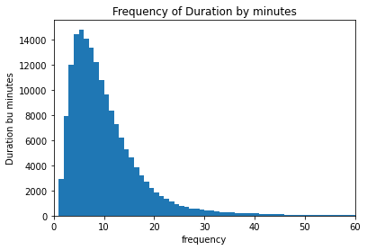

```python
# Create a histogram to show the frequency of duration_by_minutes
bins = np.arange(0, df_2['duration_by_minutes'].max()+1, 1)
plt.hist(data = df_2, x = 'duration_by_minutes', bins = bins)
plt.xlim([0,60])
plt.xlabel('frequency')
plt.ylabel('Duration bu minutes')
plt.title('Frequency of Duration by minutes')
plt.show()
```

###### User_type

What user type have the highest ride?

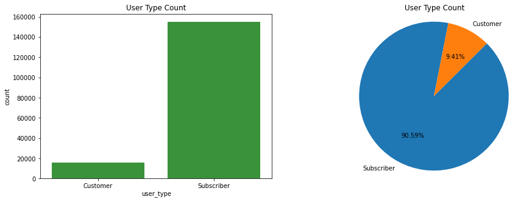

```python
# plot a bar chart showing counts of user types
plt.figure (figsize = [15, 5])
plt.subplot(1, 2, 1)
base_color = sb.color_palette()[2]
sb.countplot(data=df_2, x='user_type', color=base_color)
plt.title('User Type Count');
# plot a pie chart showing percentage counts of user types
plt.subplot(1, 2, 2)
user_counts = df_2['user_type'].value_counts()
plt.pie(user_counts, labels = user_counts.index, startangle = 45,
        counterclock = False, autopct='%1.2f%%');
plt.axis('square')
plt.title('User Type Count');
```

> Subscribers made the highest ride as seen on the charts above.

### Member_gender

What gender made the highest ride in 2019?

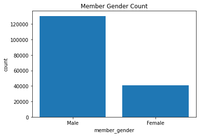

```python
# Return the Series having unique values
x = df_2['member_gender'].unique()

# Return the Series having frequency count of each unique value
y = df_2['member_gender'].value_counts(sort=False)

plt.bar(x, y)

# Labeling the axes
plt.xlabel('member_gender')
plt.ylabel('count')
plt.title('Member Gender Count')
# Dsiplay the plot
plt.show()
```

> The male gender made the highest ride in 2019.

### Start_station

what is name of the most popular start station?

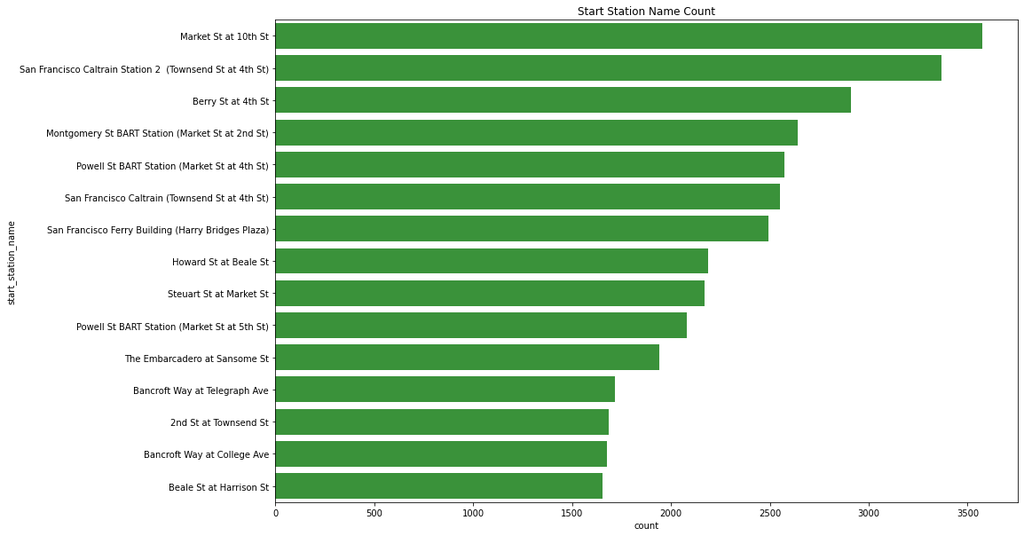

```python
# Plot the start_station_name on a horizontal bar chart. Due to the large number of stations, the first 15 stations will be selected.
plot_order = df_2['start_station_name'].value_counts().index[:15]
plt.figure(figsize=[15,10])
plt.title('Start Station Name Count')
sb.countplot(data=df_2, y='start_station_name', color=base_color, order = plot_order);
```

> Market st at 10th st is the most popular start station

### end_station

what is name of the most popular end station?

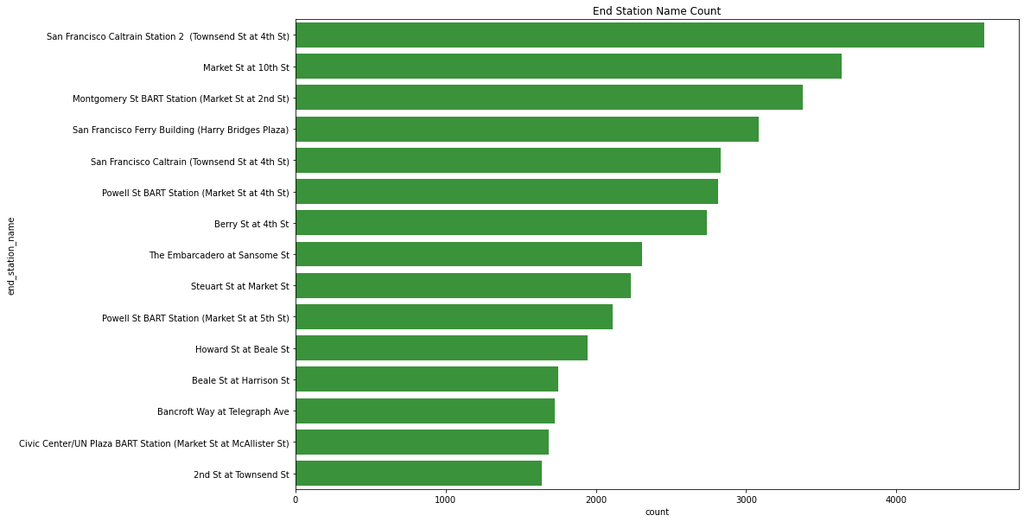

```python
# Plot the end_station_name on a horizontal bar chart. Due to the large number of stations, the first 15 stations will be selected.
plot_order = df_2['end_station_name'].value_counts().index[:15]
plt.figure(figsize=[15,10])
sb.countplot(data=df_2, y='end_station_name', color=base_color, order = plot_order);
plt.title('End Station Name Count')
```

> San Fransisco Caltrain Station 2 (Townsend St at 4th St is the most popular end station)

### Month_started

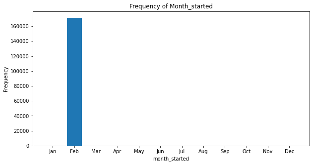

```python
# labels to use in plots
month = ['Jan', 'Feb', 'Mar', 'Apr', 'May', 'Jun', 'Jul', 'Aug', 'Sep', 'Oct', 'Nov', 'Dec']
# plot a histogram with gaps between bars
plt.figure(figsize=[10,5])
bin_edges = np.arange(0.5, 12.5+1, 1)
plt.hist(data = df_2, x = 'month_started', bins = bin_edges, rwidth = 0.7)
plt.xticks(np.arange(1, 12+1, 1), month)
plt.xlabel('month_started')
plt.ylabel('Frequency')
plt.title('Frequency of Month_started');
```

> Based on the plot, all rides were made in the month of februrary.

### Hour_started

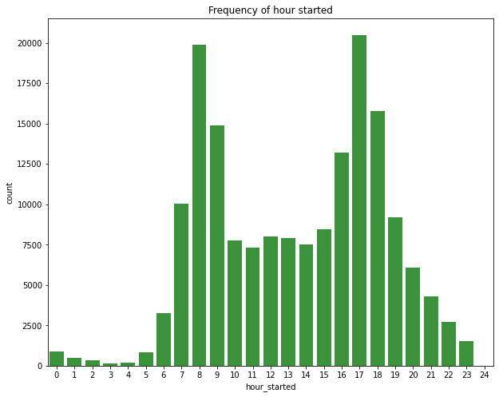

```python
# Create a plot to show the frequency of hour started
order_hour = np.arange(0,25)
plt.figure(figsize=(10,8))
sb.countplot(data=df_2, x='hour_started', order=order_hour, color=base_color);
plt.title('Frequency of hour started')
```

### Hour_ended

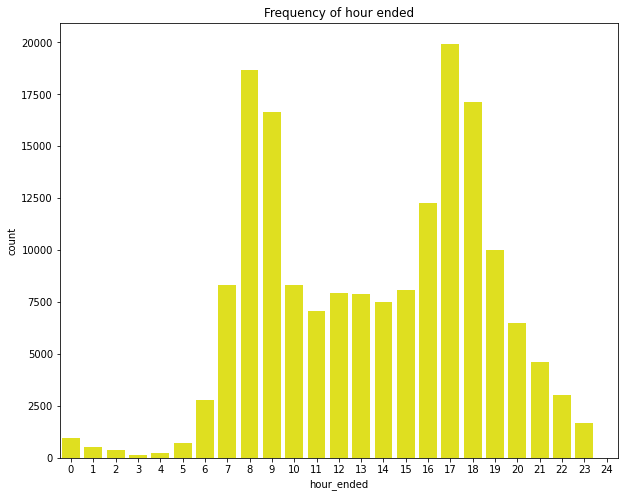

```python
# Create a plot to show the frequency of hour ended
order_hour = np.arange(0,25)
plt.figure(figsize=(10,8))
sb.countplot(data=df_2, x='hour_ended', order=order_hour, color='yellow')
plt.title('Frequency of hour ended');
```

### Member_birth_year

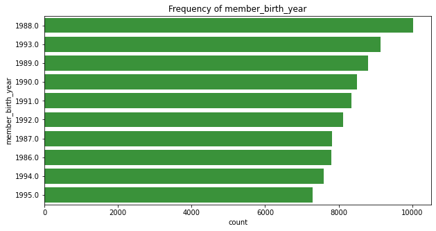

```python
# Create a plot to show the frequency of member birth year
plot_order = df_2['member_birth_year'].value_counts().index[:10]
plt.figure(figsize=[10,5])
sb.countplot(data=df_2, y='member_birth_year', color=base_color, order = plot_order);
plt.title('Frequency of member_birth_year')
```

> most members were 31 years old at the time.

### Week_started

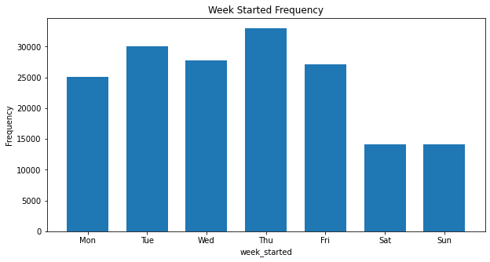

```python
weekday = ['Mon', 'Tue', 'Wed', 'Thu', 'Fri', 'Sat', 'Sun']
# plot a histogram with gaps between bars
plt.figure(figsize=[10,5])
bin_edges = np.arange(-0.5, 6.5+1, 1)
plt.hist(data = df_2, x = 'week_started', bins = bin_edges, rwidth = 0.7)
plt.xticks(np.arange(0, 6+1, 1), weekday)
plt.xlabel('week_started');
plt.ylabel('Frequency')
plt.title('Week Started Frequency')
```

### Week_ended

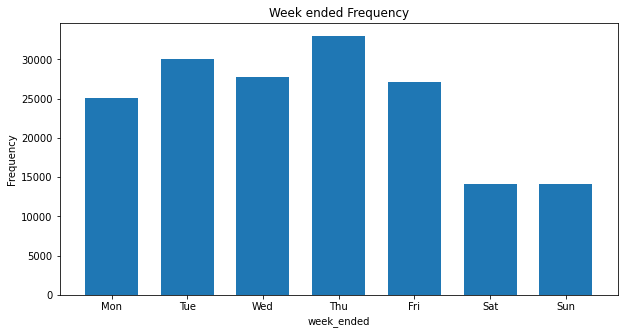

```python
# plot a histogram with gaps between bars
plt.figure(figsize=[10,5])
bin_edges = np.arange(-0.5, 6.5+1, 1)
plt.hist(data = df_2, x = 'week_ended', bins = bin_edges, rwidth = 0.7)
plt.xticks(np.arange(0, 6+1, 1), weekday)
plt.xlabel('week_ended');
plt.ylabel('Frequency')
plt.title('Week ended Frequency')
```

> Rides were mostly made on weekdays than weekends with the most rides made on thursdays.

### Of the features you investigated, were there any unusual distributions? Did you perform any operations on the data to tidy, adjust, or change the form of the data? If so, why did you do this?

> The member gender identified as 'other' seemed unsual hence it had to be dropped. Also, start and end time were splitted into month, hour and weekday with new columns created to accomodate them. Duration by second was remodified to duration by minutes on a seperate column.

## Bivariate Exploration

### Member_birth_year vs Duration_by_minutes

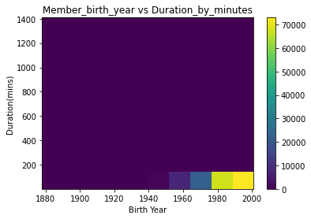

```python
# heat map
plt.hist2d(data = df_2, x = 'member_birth_year', y = 'duration_by_minutes')
plt.colorbar()
plt.xlabel('Birth Year')
plt.ylabel('Duration(mins)')
plt.title('Member_birth_year vs Duration_by_minutes');
```

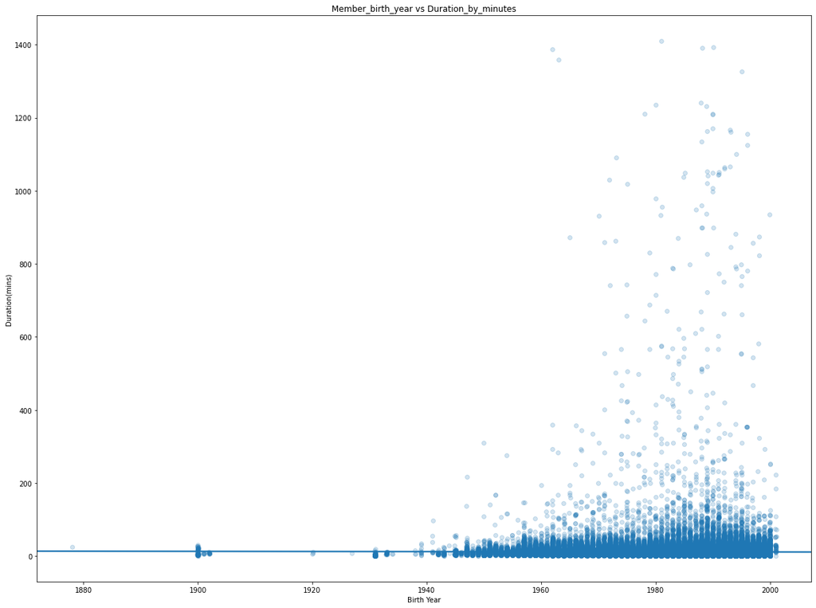

```python
#scatter plot
plt.figure(figsize = [20, 15])
sb.regplot(data = df_2, x = 'member_birth_year', y = 'duration_by_minutes', truncate=False, x_jitter=0.1, scatter_kws={'alpha':1/5});
plt.xlabel('Birth Year')
plt.ylabel('Duration(mins)')
plt.title('Member_birth_year vs Duration_by_minutes');
```

> There seems to be no strong correlation between, duration by minutes and member birth year as the heat map and the scatter plot seem not to pass on any reasonable information. To solve this problem, duration_by_minutes will be given a benchmark of 60 and the average duration will be sought.

```python
# give duration_by_minutes a benchmark of 60
dur_min = df_2[df_2.duration_by_minutes <= 60]
```

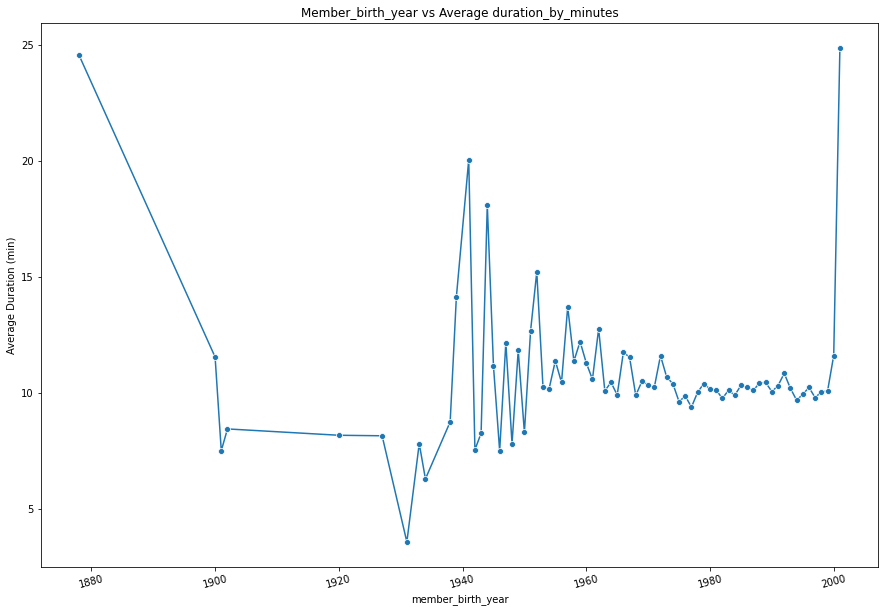

```python
# line plot showing the avaeage duration_by_minutes with members_birth_year
avg_birth = dur_min.groupby('member_birth_year').duration_by_minutes.mean()
plt.figure(figsize=[15,10])
sb.lineplot(x=avg_birth.index, y=avg_birth, marker='o')
plt.xticks (rotation=15)
plt.ylabel('Average Duration (min)')
plt.title('Member_birth_year vs Average duration_by_minutes');
```

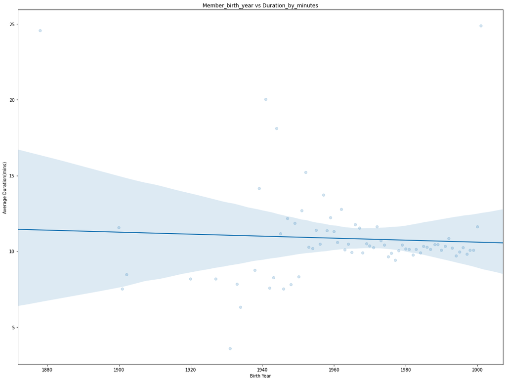

```python
#scatter plot showing the avaeage duration_by_minutes with members_birth_year
plt.figure(figsize = [20, 15])
sb.regplot(data = df_2, x=avg_birth.index, y=avg_birth, truncate=False, x_jitter=0.1, scatter_kws={'alpha':1/5})
plt.xlabel('Birth Year')
plt.ylabel('Average Duration(mins)')
plt.title('Member_birth_year vs Duration_by_minutes');
```

### member_gender vs week_started

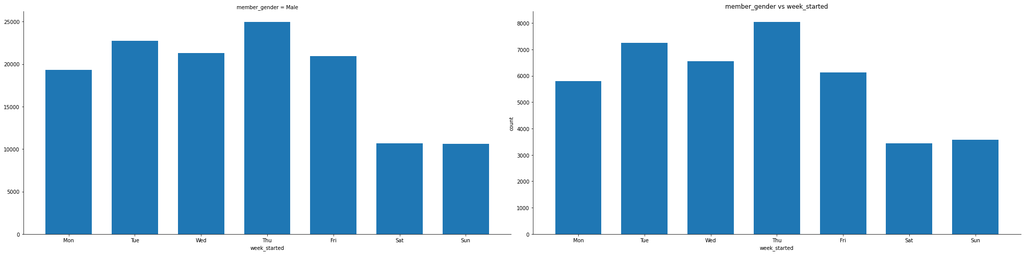

```python
# Histogram to compare member_gender and week_started
bin_edges = np.arange(-0.5, 6.5+1, 1)
g = sb.FacetGrid(data = df_2, col = 'member_gender', height=7, aspect=2,  sharey=False)
g.map(plt.hist, 'week_started', bins = bin_edges, rwidth = 0.7);
plt.xticks(np.arange(0, 6+1, 1), weekday)
plt.ylabel('count')
plt.title('member_gender vs week_started');
```

> Both male and female riders used bikes mostly on thursdays and tuesdays and least on weekends

### User_type vs hour_started

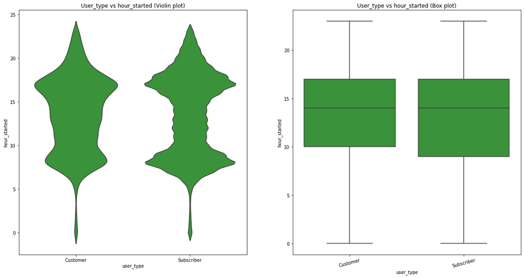

```python
# violin plot
plt.figure (figsize = [20, 10])
plt.subplot(1, 2, 1)
sb.violinplot(data=df_2, x='user_type', y='hour_started', color=base_color, inner=None)
plt.title('User_type vs hour_started (Violin plot)');
# box plot
plt.subplot(1, 2, 2)
sb.boxplot(data=df_2, x='user_type', y='hour_started', color=base_color)
plt.xticks(rotation=15)
plt.title('User_type vs hour_started (Box plot)');
```

> Both plots are bimodal and they showed that most rides for both the customers and the subscribers statrted and ended within the same time being 8:00 to 17:00

### User_type vs hour_ended

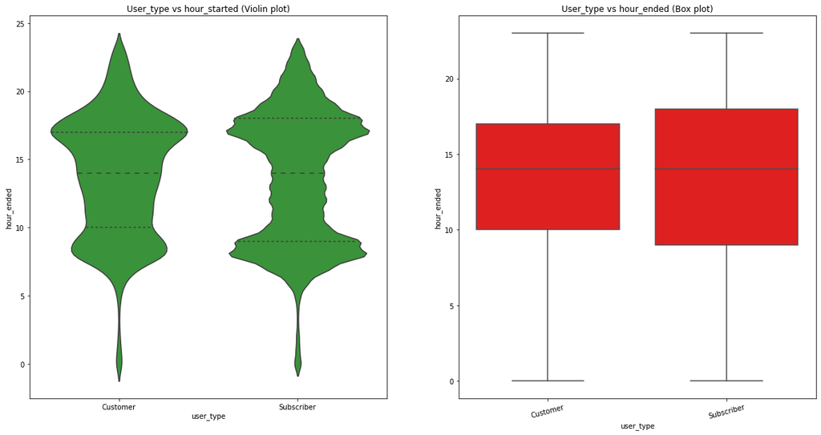

```python
# Violin Plot
plt.figure (figsize = [20, 10])
plt.subplot(1, 2, 1)
sb.violinplot(data=df_2, x='user_type', y='hour_ended', color=base_color, inner='quartile')
plt.title('User_type vs hour_started (Violin plot)');
# box plot
plt.subplot(1, 2, 2)
sb.boxplot(data=df_2, x='user_type', y='hour_ended', color='red')
plt.xticks(rotation=15)
plt.title('User_type vs hour_ended (Box plot)');
```

> As obtained in hour_started, both plots are bimodal and they showed that most rides for both the customers and the subscribers started and ended within the same time being 8:00 to 17:00 which falls within the first and fourth quartile.

### Week_started vs Average Duration

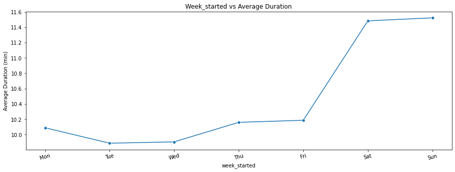

```python
# Line chart
avg_mins = dur_min.groupby('week_started').duration_by_minutes.mean()
plt.figure(figsize=[15,5])
sb.lineplot(x=avg_mins.index, y=avg_mins, marker='o')
plt.xticks(np.arange(0, 7), weekday, rotation=15)
plt.ylabel('Average Duration (min)')
plt.title('Week_started vs Average Duration');
```

> On average most bike rides lasted longer on weekends.

### Week_ended vs Average Duration

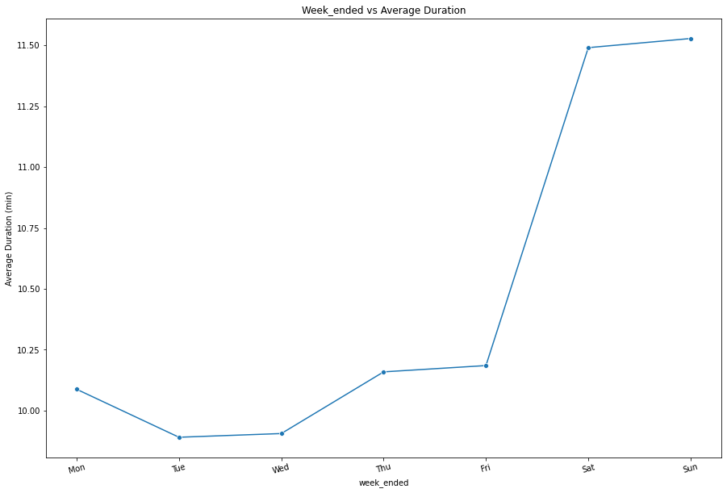

```python
# Line chart
avg_mins = dur_min.groupby('week_ended').duration_by_minutes.mean()
plt.figure(figsize=[15,10])
sb.lineplot(x=avg_mins.index, y=avg_mins, marker='o')
plt.xticks(np.arange(0, 7), weekday, rotation=15)
plt.ylabel('Average Duration (min)')
plt.title('Week_ended vs Average Duration');
```

> On average most bike rides lasted longer on weekends.

### Talk about some of the relationships you observed in this part of the investigation. How did the feature(s) of interest vary with other features in the dataset?

> No

## Multivariate Exploration

### Duration_by_minutes vs Week_started for every user_type

[figure not shown]

```python
avg = dur_min.groupby(['user_type','week_started']).duration_by_minutes.mean()
avg = avg.reset_index()

# plot a line plot with colors based on user_type
plt.figure(figsize=[10,5])
sb.lineplot(data = avg, x='week_started', y='duration_by_minutes', hue='user_type', marker='o')
plt.xticks(np.arange(1,8), weekday)
plt.ylabel('Duration Average (min)')
plt.title('Duration_by_minutes vs Week_started for every user_type');
```

> Customers had the highest average bike ride duration than subscribers

### Duration_by_minutes vs Week_ended for members_gender

[figure not shown]

```python
avg = dur_min.groupby(['member_gender','week_ended']).duration_by_minutes.mean()
avg = avg.reset_index()

# line plot based on user_type
plt.figure(figsize=[10,5])
sb.lineplot(data = avg, x='week_ended', y='duration_by_minutes', hue='member_gender', marker='o')
plt.xticks(np.arange(1,8), weekday)
plt.ylabel('Duration Average (min)')
plt.title('Duration_by_minutes vs Week_ended for members_gender');
```

> Female riders had the highest average bike ride duration than male riders

### Talk about some of the relationships you observed in this part of the investigation. Were there features that strengthened each other in terms of looking at your feature(s) of interest?

> - Customers had the highest average bike ride duration than subscribers
> - Female riders had the highest average bike ride duration than male riders

### Were there any interesting or surprising interactions between features?

> No